# Guía Introducción a los modelos lineales

Curso Introducción al Análisis de datos con R para la acuicultura

Dr. José A. Gallardo y Dra. María Angélica Rueda.

Pontificia Universidad Católica de Valparaíso  
jose.gallardo@pucv.cl

23 July 2021

### MODELOS LINEALES

Los modelos lineales son ampliamente utilizados en acuicultura para explicar, modelar o predecir la relación lineal de una variable respuesta $Y$ con una o más variables predictoras $X_1,…,X_p$.

$$Y_{i} = \beta_{0} + \beta_{1} X_{i1} + \beta_{2} \beta_{i2} + ... + \beta_{p} X_{ip} + \epsilon_{i}$$

Supuestos: $Y_i$ se distribuye **normalmente**

- Si **p = 1**, el modelo es una regresión *lineal simple*.
- Si **p > 1**, el modelo es una regresión *lineal múltiple*.
- Si **p > 1** y alguna variable predictora es **categórica**, el modelo se denomina *ANCOVA*.

### PRUEBA DE HIPÓTESIS: COEFICIENTE DE REGRESIÓN E INTERCEPTO

*Prueba de hipótesis del coeficiente de regresión y el intercepto*

La hipótesis nula en ambos casos es que el coeficiente del intercepto ($β_0$) y de la pendiente ($β_1$) son iguales a 0.

$H_0:β_0 = 0$ y $H_0:β_1 = 0$

### PREDICCIÓN A PARTIR DEL MODELO DE REGRESIÓN LINEAL SIMPLE

El Coeficiente de determinación (*R²*) se calcula como el **cuadrado del coeficiente de correlación de pearson**. Este nos indica que tan buena es la predicción que el modelo hace de los datos.

El R cuadrado ajustado (*R² ajustado*) nos dice qué porcentaje de la variación de la variable dependiente es explicado por la o las variables independientes de manera conjunta. En un modelo de regresión lineal, el **R² ajustado** es una medida de bondad que considera el número de variables existentes en el modelo.

$$R^2_{ajust} =1-(1-R^2)\frac{n-1}{n-p-1}$$

donde:

$n$ = tamaño de la muestra

$p$ = cantidad de variables predictoras en el modelo

*Prueba de hipótesis del modelo completo*

La hipótesis nula es si los coeficientes son iguales a 0.

$H_0:β_j = 0$ ; $j = 1, 2,...,k$

#### **Objetivos de aprendizaje**

Los objetivos de aprendizaje de esta guía son:

**1**. - Realizar análisis de datos usando modelos lineales.

**2**. - Realizar gráficas avanzadas con ggplot2.

**3**. - Elaborar un reporte dinámico en formato pdf con **[Rmarkdown](https://rmarkdown.rstudio.com/)**.

## ESTUDIO DE CASO: SALMON EN CONDICIONES DE CAMPO

En este estudio de caso trabajaremos con un set de datos simulado de 1000 peces cultivados bajo condiciones de campo.

La variable respuesta se denomina **weight** y se expresa en gramos. Para este set de datos existen dos variables predictoras que se deberán analizar: 1) **Geno**: que corresponde al genotipo de los peces; 2) **Sex**: que corresponde al sexo de los peces.

La variable **Geno** tiene 3 niveles denominados **0, 1 y 2** equivalentes a los genotipos **AA, AB y BB** donde 0, 1 y 2 representan el número de alelos **B**. Esta forma numérica de representar los genotipos será util para analizar la variable **Geno** como una variable cuantitativa discreta **0, 1 y 2** o como un factor (ej. **factor(Geno)**) según sea nuestro interés. La variable **Sex** tiene dos niveles **male y female**.

### **Ejercicio 1.** Elaborar y configurar Reporte en formato .Rmd

Elabore un documento .Rmd y configure su reporte para exportar en .pdf. Instale solo las liberías que utilice para el análisis de los datos.

```r
knitr::opts_chunk$set(echo = TRUE)
library(readxl)
library(ggplot2)
library(dplyr)
library(multcomp)
```

Ejecute cada uno de los siguientes ejercicios en uno o más bloques de códigos diferentes. Sea ordenado y documente su reporte adecuadamente.

### **Ejercicio 2.** Exploratorio set de datos snp.data

Importe el set de datos **snp.data.xlsx** y transforme solo la variable **Sex** a factor, luego realice un análisis exploratorio de datos.

Incluya:

**a).** Resumen estadístico de todas las variables.

```r
snp.data <- read_excel("snp.data.xlsx")

snp.data$Sex <- as.factor(snp.data$Sex)
summary(snp.data)
```

```
##      animal           weight          Geno           Sex
##  Min.   :   1.0   Min.   :1533   Min.   :0.000   female:500
##  1st Qu.: 250.8   1st Qu.:4139   1st Qu.:0.000   male  :500
##  Median : 500.5   Median :4852   Median :1.000
##  Mean   : 500.5   Mean   :4829   Mean   :0.812
##  3rd Qu.: 750.2   3rd Qu.:5507   3rd Qu.:1.000
##  Max.   :1000.0   Max.   :9347   Max.   :2.000
```

**b).** Tabla de frecuencia combinada **Geno** por **Sex**, esto es importante para ver esi los datos son o no balanceados.

```r
table(snp.data$Sex, snp.data$Geno)
```

```
##
##            0   1   2
##   female 279 197  24
##   male    72 289 139
```

```r
tapply(snp.data$weight, factor(snp.data$Geno), mean)
```

```
##        0        1        2
## 4064.509 4997.933 5972.350
```

```r
tapply(snp.data$weight, factor(snp.data$Sex), mean)
```

```
##   female     male
## 4169.323 5488.939
```

**c).** Histograma de la variable respuesta **weight**.

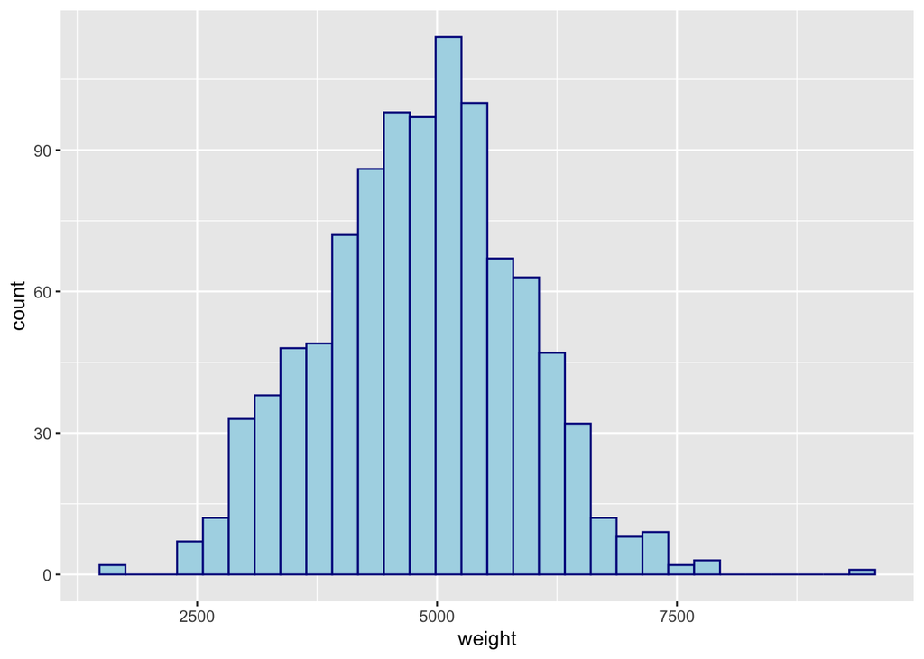

```r
ggplot(snp.data, aes(x=weight))+
  geom_histogram(color="darkblue", fill="lightblue")
```

### **Ejercicio 3.** Regresión lineal simple.

**a).** Realice una gráfica de dispersión (geom_point) de **weight** en función de **Geno**, incluya el comando **geom_smooth(method=lm)** para agregar la línea de regresión a la gráfica.

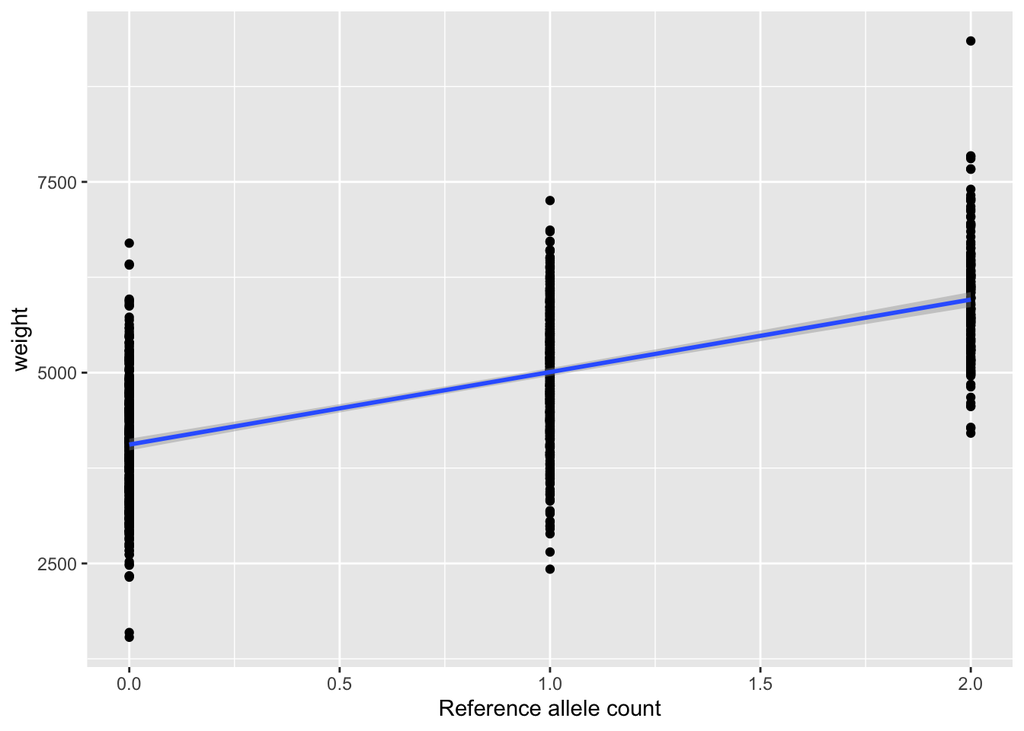

```r
p <- ggplot(snp.data, aes(x = Geno, y = weight))
p + geom_point() + xlab("Reference allele count") + geom_smooth(method=lm)
```

**b).** Realice un análisis de regresión lineal para investigar la asociación entre **weight** y **Geno** usando las funciones **lm()**, **summary()**. Interprete los resultados del modelo lineal y responda las siguientes preguntas. ¿Qué representa el estimador de Geno y del intercepto?. ¿La pendiente es significativamente distinta de cero?. ¿Y el intercepto?

```r
lm.geno <- lm(weight ~ Geno, data = snp.data)
summary(lm.geno)
```

```
##
## Call:
## lm(formula = weight ~ Geno, data = snp.data)
##
## Residuals:
##     Min      1Q  Median      3Q     Max
## -2582.5  -566.0    17.5   510.7  3389.2
##
## Coefficients:
##             Estimate Std. Error t value Pr(>|t|)
## (Intercept)  4057.72      39.14  103.68   <2e-16 ***
## Geno          950.01      36.69   25.89   <2e-16 ***
## ---
## Signif. codes:  0 '***' 0.001 '**' 0.01 '*' 0.05 '.' 0.1 ' ' 1
##
## Residual standard error: 802.6 on 998 degrees of freedom
## Multiple R-squared:  0.4019, Adjusted R-squared:  0.4013
## F-statistic: 670.6 on 1 and 998 DF,  p-value: < 2.2e-16
```

**c).** Realice la predicción de la media poblacional de **weight** para los genotipos AA, AB y BB y la predicción del peso **weight** de tres nuevos individuos con genotipo AA, AB y BB. ¿Qué tan buena son las predicciones obtenidas? Analice el R² ajustado y los intervalos de confianza.

```r
predict.lm(lm.geno, newdata=data.frame(Geno=c(0,1,2)), interval="confidence")
```

```
##        fit      lwr      upr
## 1 4057.724 3980.926 4134.523
## 2 5007.732 4956.119 5059.346
## 3 5957.740 5858.768 6056.712
```

```r
predict.lm(lm.geno, newdata=data.frame(Geno=c(0,1,2)), interval="prediction")
```

```
##        fit      lwr      upr
## 1 4057.724 2480.806 5634.643
## 2 5007.732 3431.840 6583.625
## 3 5957.740 4379.587 7535.894
```

**d).** Realice una anova del modelo lineal con la función **anova()** (supone varianzas homogeneas) y compare con una anova que no supone varianzas homogeneas **oneway.test()**

```r
# anova suponiendo varianzas iguales
anova(lm.geno)
```

```
## Analysis of Variance Table
##
## Response: weight
##            Df    Sum Sq   Mean Sq F value    Pr(>F)
## Geno        1 431994309 431994309  670.57 < 2.2e-16 ***
## Residuals 998 642935439    644224
## ---
## Signif. codes:  0 '***' 0.001 '**' 0.01 '*' 0.05 '.' 0.1 ' ' 1
```

```r
# anova suponiendo varianzas diferentes
oneway.test(weight ~ Geno, data = snp.data)
```

```
##
##  One-way analysis of means (not assuming equal variances)
##
## data:  weight and Geno
## F = 319.34, num df = 2.00, denom df = 434.21, p-value < 2.2e-16
```

**e)** El siguiente modelo lineal permite realizar pruebas de contraste entre los tres diferentes genotipos.

lm(weight ~ -1 + factor(Geno), data = snp.data)

Compare los Betas y el
$$R^2$$
de este modelo con el realizado en el ejercicio b.

```r
lm.geno2 <- lm(weight ~ -1 + factor(Geno), data = snp.data)

summary(lm.geno2)
```

```
##
## Call:
## lm(formula = weight ~ -1 + factor(Geno), data = snp.data)
##
## Residuals:
##     Min      1Q  Median      3Q     Max
## -2572.7  -570.9    19.1   516.5  3374.6
##
## Coefficients:
##               Estimate Std. Error t value Pr(>|t|)
## factor(Geno)0  4064.51      42.86   94.83   <2e-16 ***
## factor(Geno)1  4997.93      36.42  137.22   <2e-16 ***
## factor(Geno)2  5972.35      62.89   94.96   <2e-16 ***
## ---
## Signif. codes:  0 '***' 0.001 '**' 0.01 '*' 0.05 '.' 0.1 ' ' 1
##
## Residual standard error: 803 on 997 degrees of freedom
## Multiple R-squared:  0.9736, Adjusted R-squared:  0.9736
## F-statistic: 1.228e+04 on 3 and 997 DF,  p-value: < 2.2e-16
```

```r
summary(lm.geno)
```

```
##
## Call:
## lm(formula = weight ~ Geno, data = snp.data)
##
## Residuals:
##     Min      1Q  Median      3Q     Max
## -2582.5  -566.0    17.5   510.7  3389.2
##
## Coefficients:
##             Estimate Std. Error t value Pr(>|t|)
## (Intercept)  4057.72      39.14  103.68   <2e-16 ***
## Geno          950.01      36.69   25.89   <2e-16 ***
## ---
## Signif. codes:  0 '***' 0.001 '**' 0.01 '*' 0.05 '.' 0.1 ' ' 1
##
## Residual standard error: 802.6 on 998 degrees of freedom
## Multiple R-squared:  0.4019, Adjusted R-squared:  0.4013
## F-statistic: 670.6 on 1 and 998 DF,  p-value: < 2.2e-16
```

**f)** Investigue y aplique los comandos **contrMat()** y **glht** para realizar una prueba de contrastes con ajuste de bonferroni para multiples comparaciones.

```r
# Elabora matriz de contrastes para el factor Geno
contrastes = contrMat(table(snp.data$Geno), type="Tukey")

# Realiza comparaciones multiples
mc2 = glht(lm.geno2, linfct =contrastes)
summary(mc2, test=adjusted("bonferroni"))
```

```
##
##   Simultaneous Tests for General Linear Hypotheses
##
## Multiple Comparisons of Means: Tukey Contrasts
##
##
## Fit: lm(formula = weight ~ -1 + factor(Geno), data = snp.data)
##
## Linear Hypotheses:
##            Estimate Std. Error t value Pr(>|t|)
## 1 - 0 == 0   933.42      56.25   16.59   <2e-16 ***
## 2 - 0 == 0  1907.84      76.11   25.07   <2e-16 ***
## 2 - 1 == 0   974.42      72.68   13.41   <2e-16 ***
## ---
## Signif. codes:  0 '***' 0.001 '**' 0.01 '*' 0.05 '.' 0.1 ' ' 1
## (Adjusted p values reported -- bonferroni method)
```

### **Ejercicio 4.** Análisis de covarianza

**a).** Realice una gráfica de dispersión (geom_point) de **weight** en función de **Geno** y **Sex**, incluya el comando **geom_smooth(method=lm)** para agregar la línea de regresión a la gráfica.

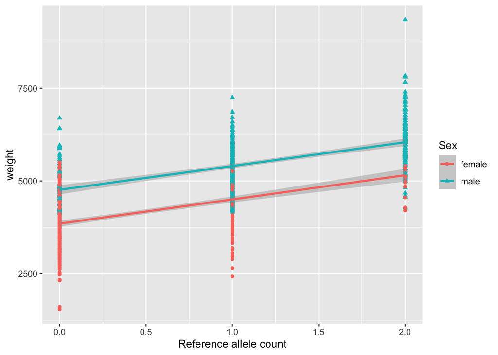

```r
q <- ggplot(snp.data, aes(x = Geno, y = weight, shape=Sex, color=Sex))
q + geom_point() + xlab("Reference allele count") + geom_smooth(method=lm)
```

**b).** Realice un análisis de covarianza para investigar la asociación entre **weight**, **Geno** y **Sex** usando las funciones **lm()**, **summary()**.

```r
lm.geno.sex <- lm(weight ~ Geno + Sex, data = snp.data)
summary(lm.geno.sex)
```

```
##
## Call:
## lm(formula = weight ~ Geno + Sex, data = snp.data)
##
## Residuals:
##     Min      1Q  Median      3Q     Max
## -2319.7  -500.4     8.1   480.0  3298.5
##
## Coefficients:
##             Estimate Std. Error t value Pr(>|t|)
## (Intercept)  3852.73      35.77  107.72   <2e-16 ***
## Geno          646.10      35.95   17.97   <2e-16 ***
## Sexmale       903.53      49.74   18.17   <2e-16 ***
## ---
## Signif. codes:  0 '***' 0.001 '**' 0.01 '*' 0.05 '.' 0.1 ' ' 1
##
## Residual standard error: 696.1 on 997 degrees of freedom
## Multiple R-squared:  0.5506, Adjusted R-squared:  0.5497
## F-statistic: 610.8 on 2 and 997 DF,  p-value: < 2.2e-16
```

**c).** Interprete los resultados del modelo lineal.

### **Ejercicio 5.** Anova 2 vías con interacción

**a).** Realice gráficas del tamaño de los efectos **plot.design()** y de interacción **interaction.plot** de **Geno** y **Sex** sobre **weight**.

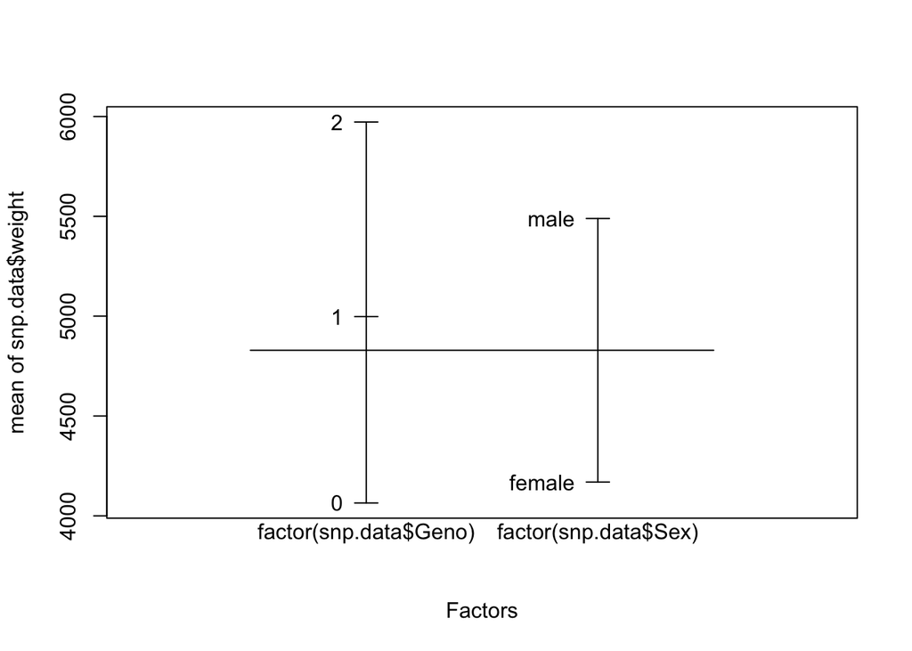

```r
plot.design(snp.data$weight ~ factor(snp.data$Geno) + factor(snp.data$Sex))
```

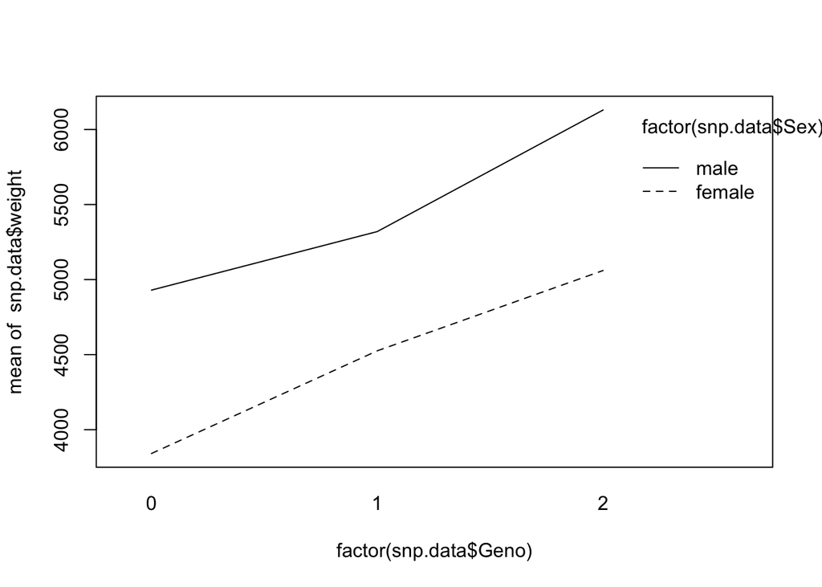

```r
interaction.plot(factor(snp.data$Geno), factor(snp.data$Sex), snp.data$weight, mean)
```

**b).** Realice un análisis de varianza con interacción para investigar la asociación entre **weight**, **Geno** y **Sex** usando las funciones **lm()**, **summary()**.

```r
lm.qtl <- lm(weight ~ factor(Geno) * factor(Sex), data = snp.data)
summary(lm.qtl)
```

```
##
## Call:
## lm(formula = weight ~ factor(Geno) * factor(Sex), data = snp.data)
##
## Residuals:
##     Min      1Q  Median      3Q     Max
## -2308.2  -503.3     0.1   487.5  3217.1
##
## Coefficients:
##                               Estimate Std. Error t value Pr(>|t|)
## (Intercept)                    3841.20      41.50  92.556  < 2e-16 ***
## factor(Geno)1                   684.27      64.51  10.607  < 2e-16 ***
## factor(Geno)2                  1219.25     147.46   8.268 4.32e-16 ***
## factor(Sex)male                1088.64      91.63  11.881  < 2e-16 ***
## factor(Geno)1:factor(Sex)male  -294.11     111.80  -2.631  0.00865 **
## factor(Geno)2:factor(Sex)male   -19.29     178.54  -0.108  0.91397
## ---
## Signif. codes:  0 '***' 0.001 '**' 0.01 '*' 0.05 '.' 0.1 ' ' 1
##
## Residual standard error: 693.2 on 994 degrees of freedom
## Multiple R-squared:  0.5556, Adjusted R-squared:  0.5534
## F-statistic: 248.6 on 5 and 994 DF,  p-value: < 2.2e-16
```

**c).** Interprete los resultados del modelo lineal.